# Analyzing the Red Wine Data Set by Jon Baker

### Introducing the Red Wine Data Set

This data set looks at over 1,000 red wines. It looks like there are 13 variables to look at, with one of them being a primary key. I notice that some variables operate on different orders of magnitude than others.

# Univariate Plots Section

Here are some summaries of the data set’s variables.

```
##  [1] "X"                    "fixed.acidity"        "volatile.acidity"
##  [4] "citric.acid"          "residual.sugar"       "chlorides"
##  [7] "free.sulfur.dioxide"  "total.sulfur.dioxide" "density"
## [10] "pH"                   "sulphates"            "alcohol"
## [13] "quality"
```

```
## 'data.frame':    1599 obs. of  13 variables:
##  $ X                   : int  1 2 3 4 5 6 7 8 9 10 ...
##  $ fixed.acidity       : num  7.4 7.8 7.8 11.2 7.4 7.4 7.9 7.3 7.8 7.5 ...
##  $ volatile.acidity    : num  0.7 0.88 0.76 0.28 0.7 0.66 0.6 0.65 0.58 0.5 ...
##  $ citric.acid         : num  0 0 0.04 0.56 0 0 0.06 0 0.02 0.36 ...
##  $ residual.sugar      : num  1.9 2.6 2.3 1.9 1.9 1.8 1.6 1.2 2 6.1 ...
##  $ chlorides           : num  0.076 0.098 0.092 0.075 0.076 0.075 0.069 0.065 0.073 0.071 ...
##  $ free.sulfur.dioxide : num  11 25 15 17 11 13 15 15 9 17 ...
##  $ total.sulfur.dioxide: num  34 67 54 60 34 40 59 21 18 102 ...
##  $ density             : num  0.998 0.997 0.997 0.998 0.998 ...
##  $ pH                  : num  3.51 3.2 3.26 3.16 3.51 3.51 3.3 3.39 3.36 3.35 ...
##  $ sulphates           : num  0.56 0.68 0.65 0.58 0.56 0.56 0.46 0.47 0.57 0.8 ...
##  $ alcohol             : num  9.4 9.8 9.8 9.8 9.4 9.4 9.4 10 9.5 10.5 ...
##  $ quality             : int  5 5 5 6 5 5 5 7 7 5 ...
```

```
##        X          fixed.acidity   volatile.acidity  citric.acid
##  Min.   :   1.0   Min.   : 4.60   Min.   :0.1200   Min.   :0.000
##  1st Qu.: 400.5   1st Qu.: 7.10   1st Qu.:0.3900   1st Qu.:0.090
##  Median : 800.0   Median : 7.90   Median :0.5200   Median :0.260
##  Mean   : 800.0   Mean   : 8.32   Mean   :0.5278   Mean   :0.271
##  3rd Qu.:1199.5   3rd Qu.: 9.20   3rd Qu.:0.6400   3rd Qu.:0.420
##  Max.   :1599.0   Max.   :15.90   Max.   :1.5800   Max.   :1.000
##  residual.sugar     chlorides       free.sulfur.dioxide total.sulfur.dioxide
##  Min.   : 0.900   Min.   :0.01200   Min.   : 1.00       Min.   :  6.00
##  1st Qu.: 1.900   1st Qu.:0.07000   1st Qu.: 7.00       1st Qu.: 22.00
##  Median : 2.200   Median :0.07900   Median :14.00       Median : 38.00
##  Mean   : 2.539   Mean   :0.08747   Mean   :15.87       Mean   : 46.47
##  3rd Qu.: 2.600   3rd Qu.:0.09000   3rd Qu.:21.00       3rd Qu.: 62.00
##  Max.   :15.500   Max.   :0.61100   Max.   :72.00       Max.   :289.00
##     density             pH          sulphates         alcohol
##  Min.   :0.9901   Min.   :2.740   Min.   :0.3300   Min.   : 8.40
##  1st Qu.:0.9956   1st Qu.:3.210   1st Qu.:0.5500   1st Qu.: 9.50
##  Median :0.9968   Median :3.310   Median :0.6200   Median :10.20
##  Mean   :0.9967   Mean   :3.311   Mean   :0.6581   Mean   :10.42
##  3rd Qu.:0.9978   3rd Qu.:3.400   3rd Qu.:0.7300   3rd Qu.:11.10
##  Max.   :1.0037   Max.   :4.010   Max.   :2.0000   Max.   :14.90
##     quality
##  Min.   :3.000
##  1st Qu.:5.000
##  Median :6.000
##  Mean   :5.636
##  3rd Qu.:6.000
##  Max.   :8.000
```

There is a primary key, 11 variables, and 1 quality variable that can be used as a categorical variable.

Here are some charts looking at all of the variables in the data set.

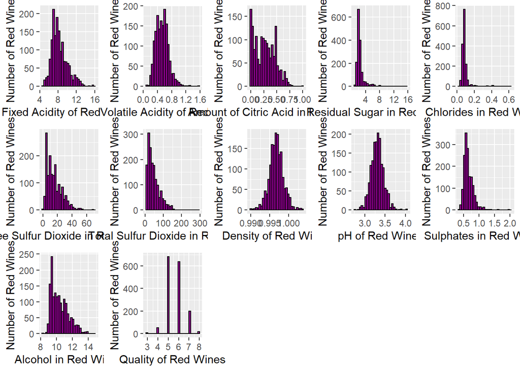

These visualizations were created in order to get a feel for the variables. We can see that the “Quality of Red Wines” chart is based on integers, not real numbers. “Fixed Acidity,” “Density,” “Volatile Acidity” and “pH” have the most normal-looking curves out of the bunch. Many of these charts have tails on the right, including the “Sulfur Dioxide” charts, “Sulphates” chart, “Alcohol” chart and especially the “Residual Sugar” and “Chlorides” charts.

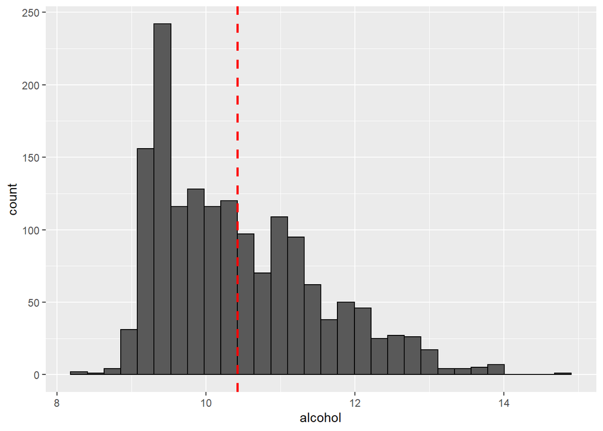

```
##    Min. 1st Qu.  Median    Mean 3rd Qu.    Max.
##    8.40    9.50   10.20   10.42   11.10   14.90
```

Here is a close-up view of alcohol content. This is an important feature in wines. We can see the mean is around 10.5 % or so. It will be interesting to look this over in the multivariate analysis, as it is correlated with quality.

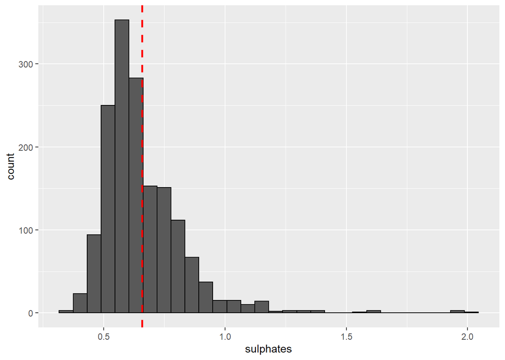

```
##    Min. 1st Qu.  Median    Mean 3rd Qu.    Max.
##  0.3300  0.5500  0.6200  0.6581  0.7300  2.0000
```

This is a histogram of sulfate content in red wines. You can see here that the mean is around .65 mg/l or so. This will also be interesting in the multivariate analysis, as it is correlated with quality.

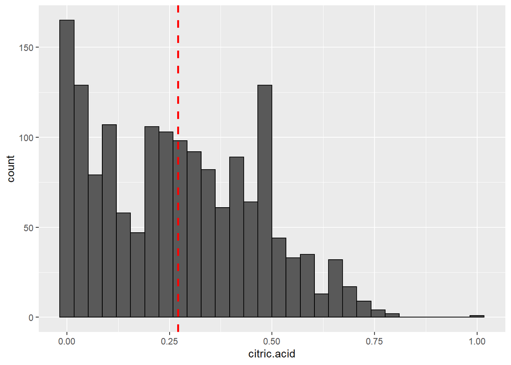

```
##    Min. 1st Qu.  Median    Mean 3rd Qu.    Max.
##   0.000   0.090   0.260   0.271   0.420   1.000
```

Citric Acid is positively correlated with the quality of red wines. We can see here that the mean is around 0.25 g/L, and this is not a normal histogram at all, but an entirely different shape.

It will be interesting to look at a multivariate analysis of this chart with regards to quality.

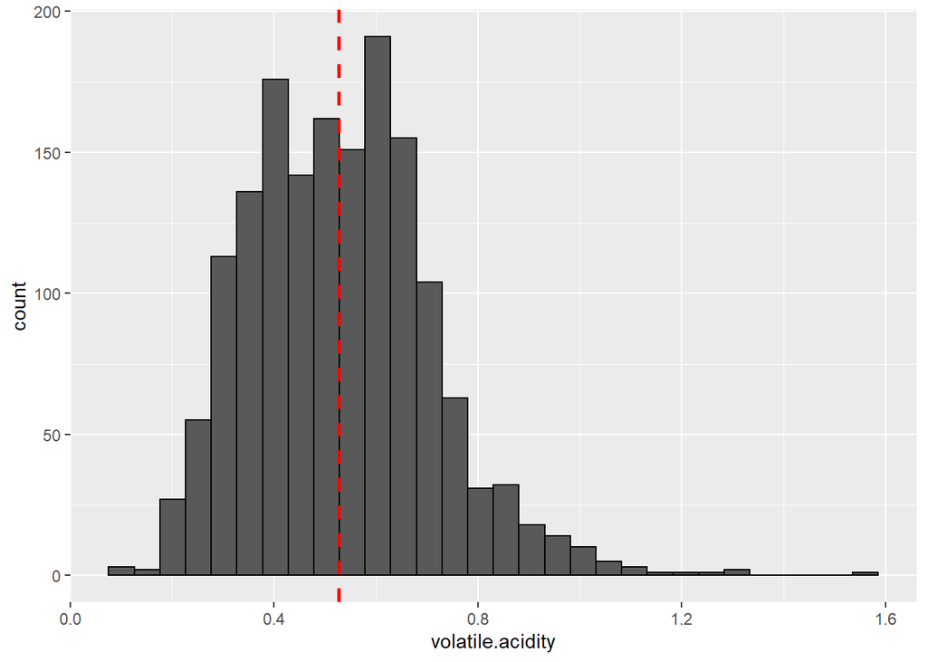

```
##    Min. 1st Qu.  Median    Mean 3rd Qu.    Max.
##  0.1200  0.3900  0.5200  0.5278  0.6400  1.5800
```

Volatile Acidity is important, as we find out later, because it is negatively associated with red wine quality. Here, we can see the mean is around 0.5 g/L.

This looks like a normal curve with a right tail. It will be interesting to look at a multivariate analysis of this chart with regards to quality.

# Univariate Analysis

### What is the structure of your dataset?

This data set is structured with 11 numeric variables and 1 categorical variable (quality). There is also the primary key in a column by itself. To be more specific, all of the variables except for quality are numeric and real. However, the variable for quality is numeric and an integer. I will have to transform it, but it should work very well.

### What is/are the main feature(s) of interest in your dataset?

The categorical variable called quality could be useful when doing a multivariate analysis. Density, pH, sulphites and alcohol content are tracked. In addition, fixed acidity, volatile acidity, citric acid, residual sugar, chlorides, free sulfur dioxide and total sulfur dioxide are tracked.

I am not sure what others would be interested in, but I am interested in how acids affect things like pH and density. I already know that more acid means less pH, but I would like to see it in action with the data. I want to check and see if more citric acid makes more fixed acidity.

Others might be interested in how alcohol content, sulfates, residual sugars, citric acid and even pH affect the quality rating. So we will look into that as well.

### What other features in the dataset do you think will help support your investigation into your feature(s) of interest?

I really like how quality is an integer. This makes it a candidate for helping out with multivariate analysis.

### Did you create any new variables from existing variables in the dataset?

I did not create any new variables.

### Of the features you investigated, were there any unusual distributions? Did you perform any operations on the data to tidy, adjust, or change the form of the data? If so, why did you do this?

Two of the variables, residual sugar and chlorides, have long tails on the right and I would prefer to chop those off if I were to use those graphs in a presentation.

# Bivariate Plots Section

### These are the correlation values of that data. From this, there are a few relationships we can look into.

```
##                                 X fixed.acidity volatile.acidity citric.acid
## X                     1.000000000   -0.26848392     -0.008815099 -0.15355136
## fixed.acidity        -0.268483920    1.00000000     -0.256130895  0.67170343
## volatile.acidity     -0.008815099   -0.25613089      1.000000000 -0.55249568
## citric.acid          -0.153551355    0.67170343     -0.552495685  1.00000000
## residual.sugar       -0.031260835    0.11477672      0.001917882  0.14357716
## chlorides            -0.119868519    0.09370519      0.061297772  0.20382291
## free.sulfur.dioxide   0.090479643   -0.15379419     -0.010503827 -0.06097813
## total.sulfur.dioxide -0.117849669   -0.11318144      0.076470005  0.03553302
## density              -0.368372087    0.66804729      0.022026232  0.36494718
## pH                    0.136005328   -0.68297819      0.234937294 -0.54190414
## sulphates            -0.125306999    0.18300566     -0.260986685  0.31277004
## alcohol               0.245122841   -0.06166827     -0.202288027  0.10990325
## quality               0.066452608    0.12405165     -0.390557780  0.22637251
##                      residual.sugar    chlorides free.sulfur.dioxide
## X                      -0.031260835 -0.119868519         0.090479643
## fixed.acidity           0.114776724  0.093705186        -0.153794193
## volatile.acidity        0.001917882  0.061297772        -0.010503827
## citric.acid             0.143577162  0.203822914        -0.060978129
## residual.sugar          1.000000000  0.055609535         0.187048995
## chlorides               0.055609535  1.000000000         0.005562147
## free.sulfur.dioxide     0.187048995  0.005562147         1.000000000
## total.sulfur.dioxide    0.203027882  0.047400468         0.667666450
## density                 0.355283371  0.200632327        -0.021945831
## pH                     -0.085652422 -0.265026131         0.070377499
## sulphates               0.005527121  0.371260481         0.051657572
## alcohol                 0.042075437 -0.221140545        -0.069408354
## quality                 0.013731637 -0.128906560        -0.050656057
##                      total.sulfur.dioxide     density          pH    sulphates
## X                             -0.11784967 -0.36837209  0.13600533 -0.125306999
## fixed.acidity                 -0.11318144  0.66804729 -0.68297819  0.183005664
## volatile.acidity               0.07647000  0.02202623  0.23493729 -0.260986685
## citric.acid                    0.03553302  0.36494718 -0.54190414  0.312770044
## residual.sugar                 0.20302788  0.35528337 -0.08565242  0.005527121
## chlorides                      0.04740047  0.20063233 -0.26502613  0.371260481
## free.sulfur.dioxide            0.66766645 -0.02194583  0.07037750  0.051657572
## total.sulfur.dioxide           1.00000000  0.07126948 -0.06649456  0.042946836
## density                        0.07126948  1.00000000 -0.34169933  0.148506412
## pH                            -0.06649456 -0.34169933  1.00000000 -0.196647602
## sulphates                      0.04294684  0.14850641 -0.19664760  1.000000000
## alcohol                       -0.20565394 -0.49617977  0.20563251  0.093594750
## quality                       -0.18510029 -0.17491923 -0.05773139  0.251397079
##                          alcohol     quality
## X                     0.24512284  0.06645261
## fixed.acidity        -0.06166827  0.12405165
## volatile.acidity     -0.20228803 -0.39055778
## citric.acid           0.10990325  0.22637251
## residual.sugar        0.04207544  0.01373164
## chlorides            -0.22114054 -0.12890656
## free.sulfur.dioxide  -0.06940835 -0.05065606
## total.sulfur.dioxide -0.20565394 -0.18510029
## density              -0.49617977 -0.17491923
## pH                    0.20563251 -0.05773139
## sulphates             0.09359475  0.25139708
## alcohol               1.00000000  0.47616632
## quality               0.47616632  1.00000000
```

Here, we can see that fixed acidity is negatively correlated with volatile acidity and positively correlated with citric acid. Acidity in general seems to be correlated with density, and also negatively correlated with pH.

What is most correlated with quality? Well, that would be alcohol content, citric acid and sulfates. In addition, volatile acidity is associated with poor quality. Residual sugars are interesting to glance at for a look at how sweetness affects red wine quality.

### Bivarate Plots

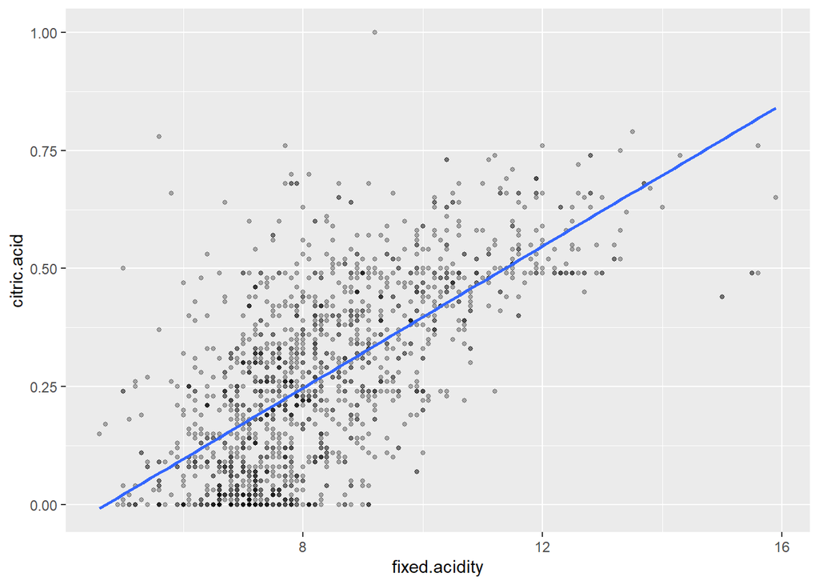

```
## [1] 0.6717034
```

Fixed acidity and citric acid are positively correlated. I wanted to see if they were related, and they are. It is imagined that citric acid causes fixed acidity.

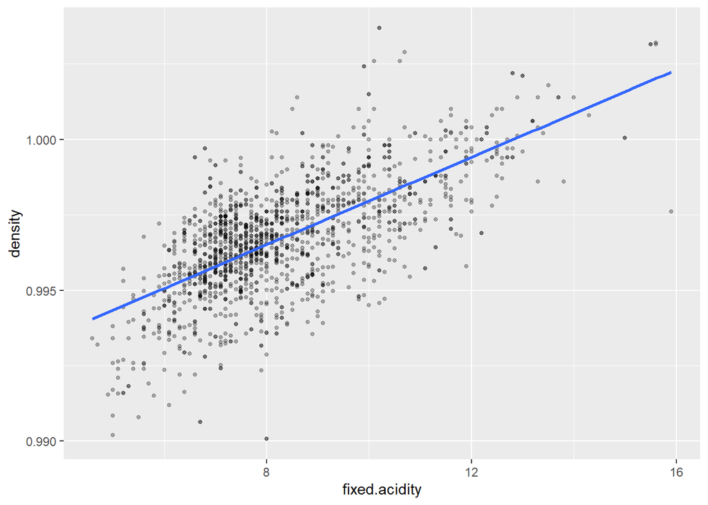

```
## [1] 0.6680473
```

Fixed acidity and density were positively correlated, meaning the more acidic something is, the denser it is. This was surprising to me! I’ve never heard of this relationship before, but I noticed it on the correlation master chart above.

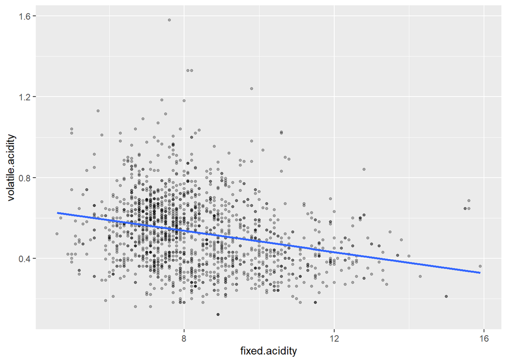

```
## [1] -0.2561309
```

Fixed acidity and volatile acidity were negatively correlated - this means they could be opposites of each other! I was interested in their relationship, and suspected as much.

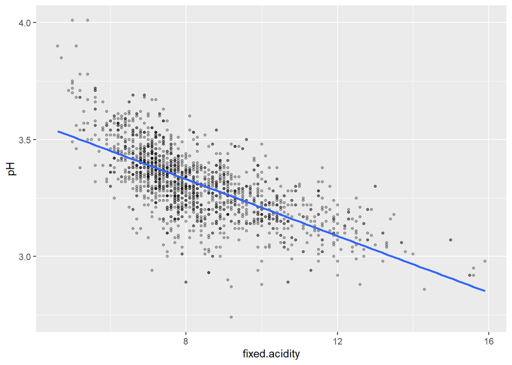

```
## [1] -0.6829782
```

Fixed acidity and pH were negatively correlated… this is because a low pH by definition means something that is more acidic. I was interested to see if my knowledge of chemistry held true here, and it did.

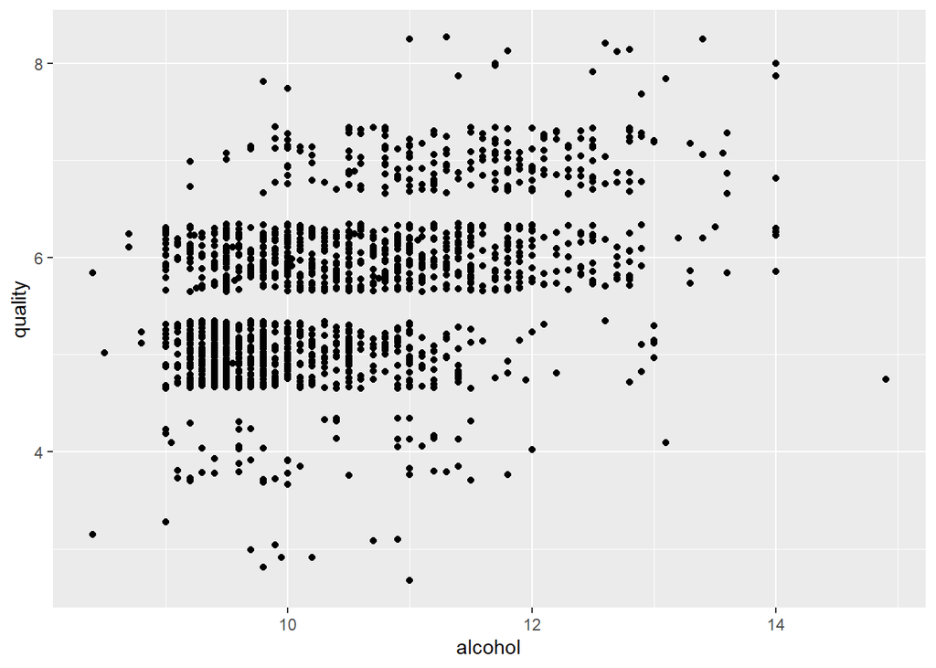

```
## [1] 0.4761663
```

The higher the alcohol content, the greater the quality of a red wine tends to be. Alcohol content was a prime indicator of quality according to the correlation overview.

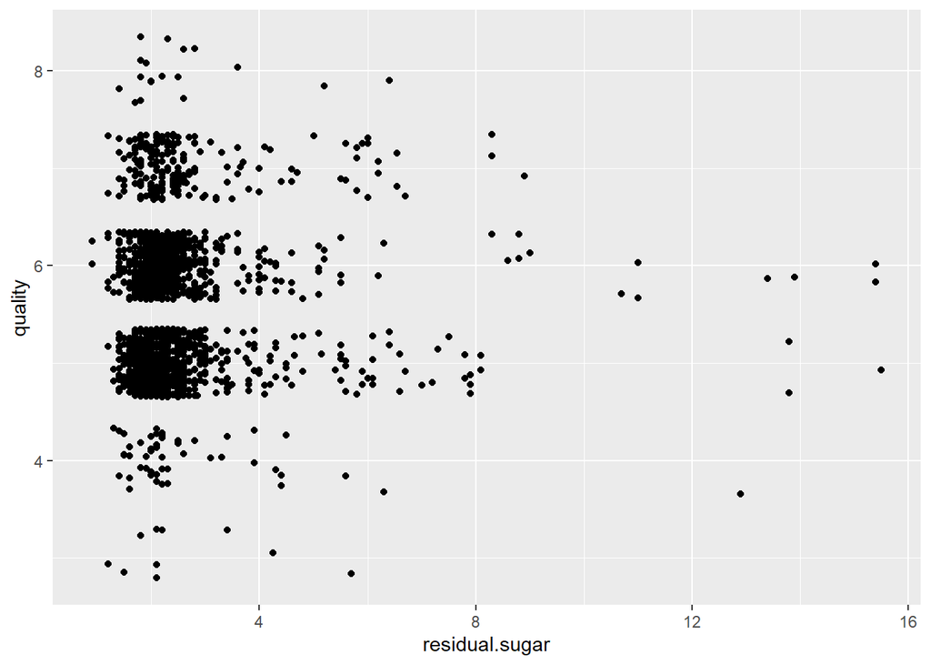

```
## [1] 0.01373164
```

Residual sugar and wine quality is hardly correlated at all, but a bit in the positive direction. I was interested in this, because sweetness is a taste that everyone can relate to, and does it affect wine quality or not?

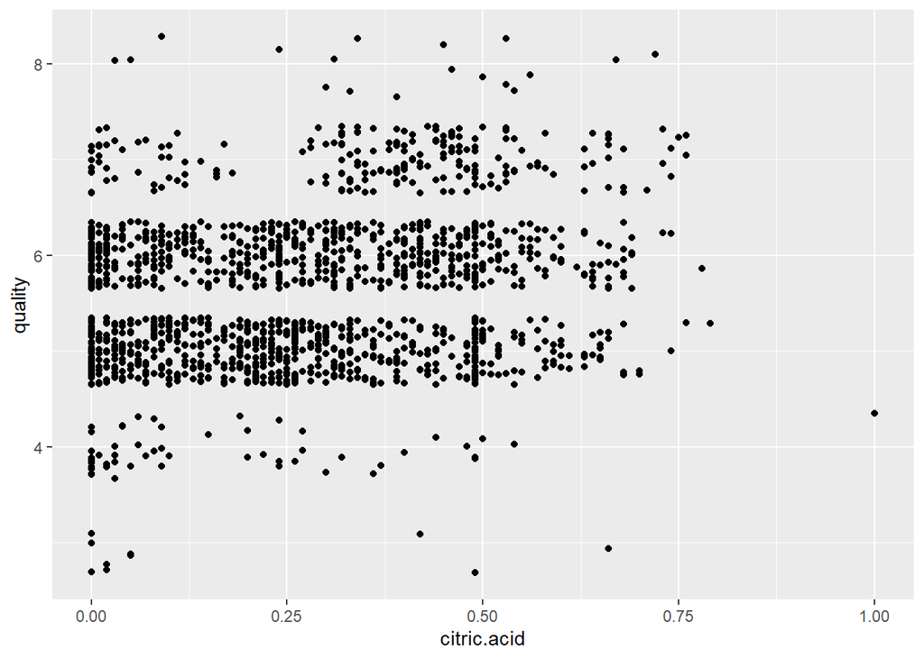

```
## [1] 0.2263725
```

Citric acid is correlated with higher-quality red wines. I noticed this on the correlation overview and wanted to take a closer look.

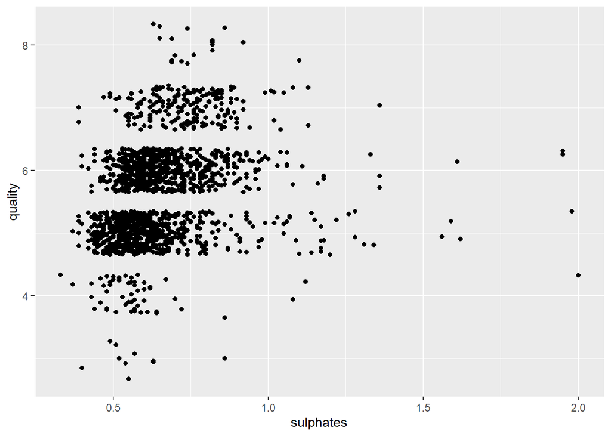

```
## [1] 0.2513971
```

More sulfates tend to exist in higher-quality red wines. I noticed this on the correlation overview and wanted to take a closer look.

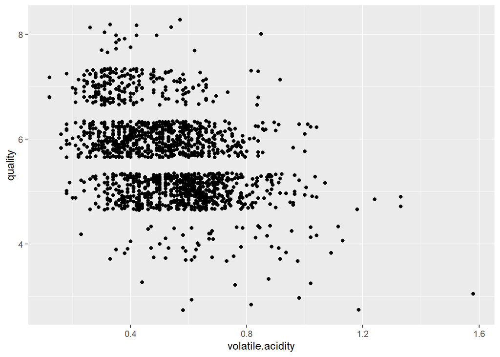

```
## [1] -0.3905578
```

The more volatile acidity a red wine has, the lower its quality rating. I noticed this on the correlation overview and wanted to take a closer look. It is unique in that it has a high negative correlation value. This could be explained because of its negative relationship with citric acid, which has a positive relationship with quality.

### Descriptions of the scatterplots

It looks like citric acid is associated with fixed acidity, with a correlation of .6717 . Fixed acidity is also positively correlated with density, with a correlation value of .6680 .

What about citric acid vs. volatile acidity? We notice a negative correlation here of -.5525, which gives us a clue to the nature of “volatile acidity” - it probably comes from something other than citric acid.

Keep reading for more information on the charts regarding quality.

# Bivariate Analysis

### Talk about some of the relationships you observed in this part of the investigation. How did the feature(s) of interest vary with other features in the dataset?

I showed a scatterplot of fixed acidity vs. citric acid to see if they were correlated, and they were, in a positive manner. Similarly, fixed acidity was positively correlated with density.

These were scientific experiments to see if increasing citric acid increased fixed acidity. I made the hypothesis that it would. In addition, I wanted to see if acids were denser than neutral substances, in general, and they were.

Interestingly enough, citric acid was negatively correlated with volatile acidity.

Volatile acidity is negatively associated with fixed acidity, and I noticed that pH tends to lower the more acids are added, which makes sense.

### Did you observe any interesting relationships between the other features (not the main feature(s) of interest)?

Quality was most highly correlated with sulfates and alcohol content, and most negatively associated with volatile acidity.

### What was the strongest relationship you found?

Fixed Acidity vs. Density was one of the strongest relationships I found, which is quite interesting! Could there be something to this?

# Multivariate Plots Section

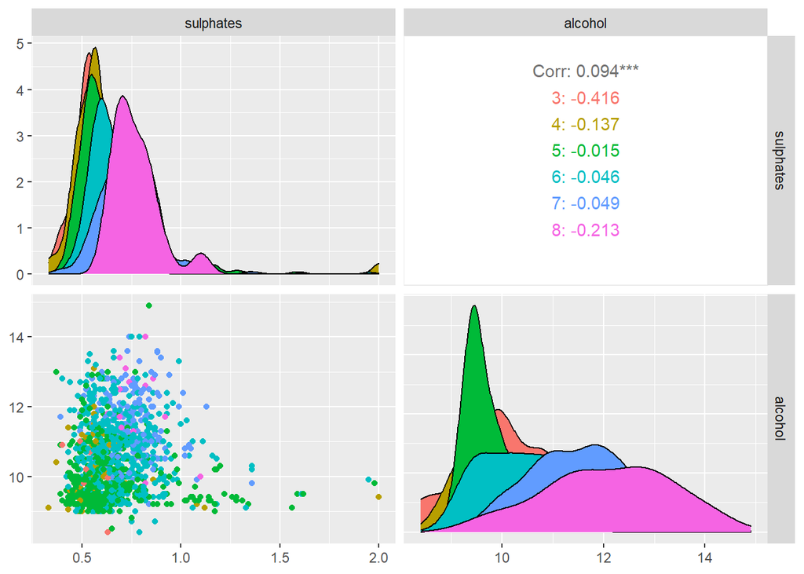

### Description of Sulphates vs. Alcohol Content with Regards to Quality

This chart shows a scatterplot of sulfates vs. alcohol content with the additional layer of quality added on top. From the alcohol chart in particular, we notice that the highest quality wines have a higher alcohol content. For sulfates, we notice the same trend - more sulfates means a higher-quality red wine.

As far as the correlation goes, for either terrible (3) or amazing (8) wines, this is where sulfates were most negatively correlated with alcohol content, with terrible wines having a correlation as small as -.416

This last part seems like something very subtle, but is it usable information if I can grasp my head around it?

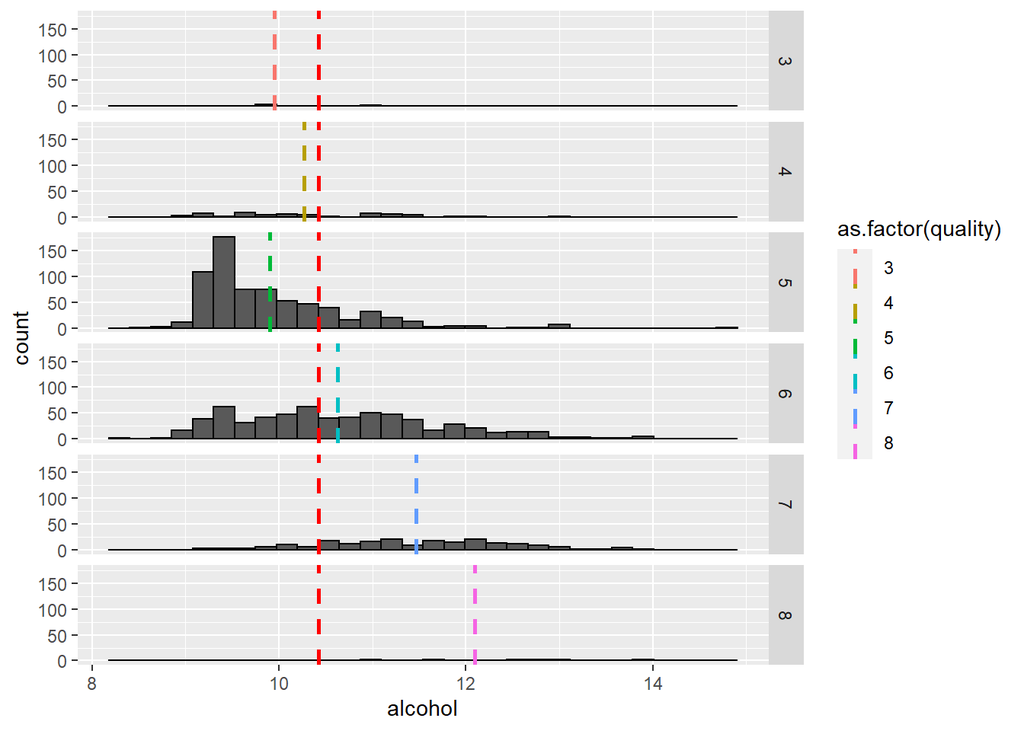

### Description of Alcohol Content in Red Wines with Regards to Quality

Here, we can see that the higher-quality red wines have a higher alcohol content. On this graph and the ones following, the mean of the entire batch will be a red line going down the chart, with the mean lines of each quality level also showing. The conclusion here would be to make your wine have as much alcohol content as possible for a high rating. The mean alcohol rating of a high-quality red wine is around 12%.

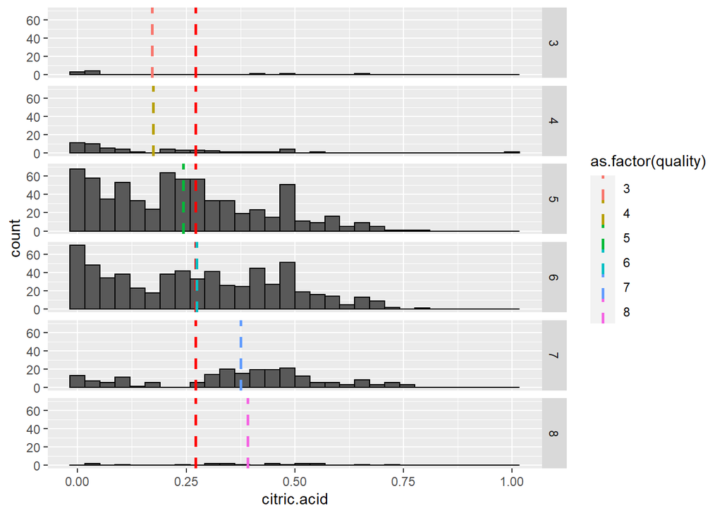

### Description of Citric Acid in Red Wines with Regards to Quality

We can see here that a higher mean of citric acid is associated with higher- quality red wines. You can see that the mean citric acid of a high-quality wine is around .4 g/L.

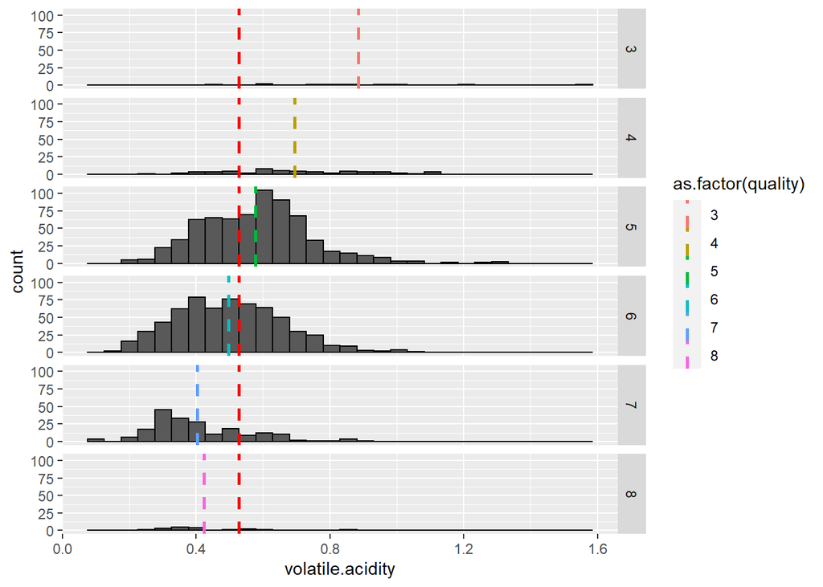

### Description of Volatile Acidity in Red Wines with Regards to Quality

We can see here that volatile acidity is, in general, less in higher-quality wines.

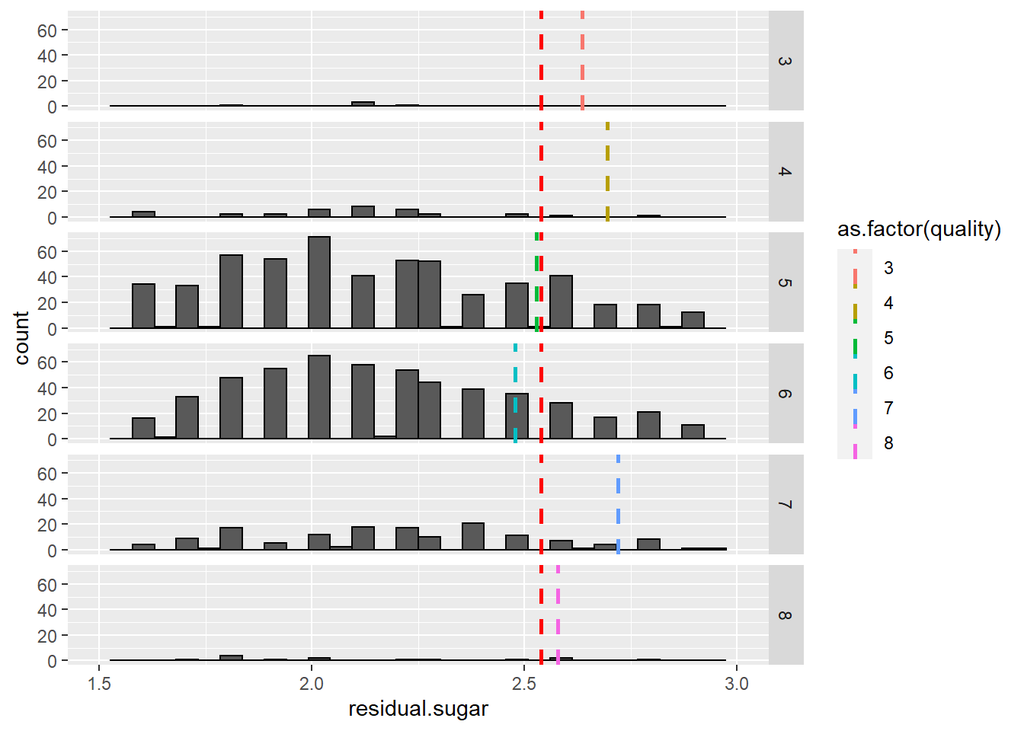

### Description of Residual Sugar in Red Wines with Regards to Quality

We can see here that a higher mean of residual sugar is associated with the extremities of wine quality. Sugar content jumps at 7, but goes back down to slightly above the mean at quality level 8.

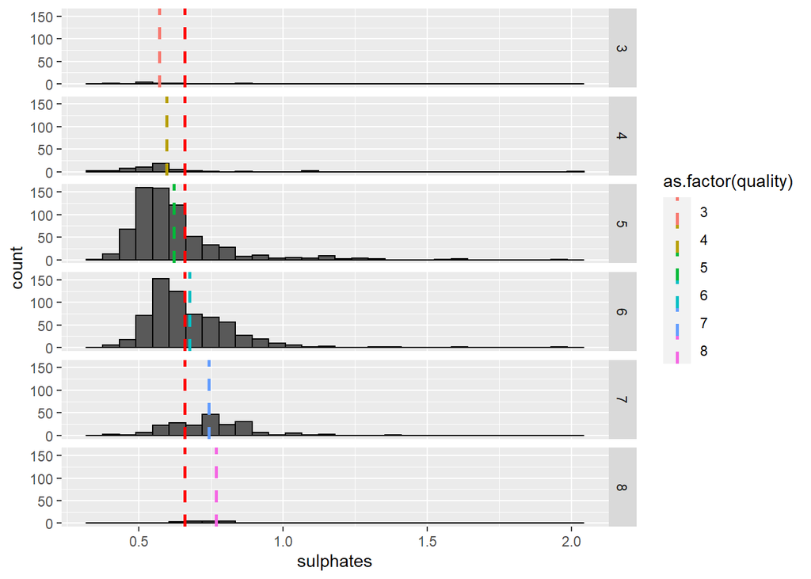

### Description of Sulfates in Red Wines with Regards to Quality

Here, we can see that higher-quality wines tend to have a higher sulfate count. In fact, the mean of quality 8 wines is around .75 mg/L.

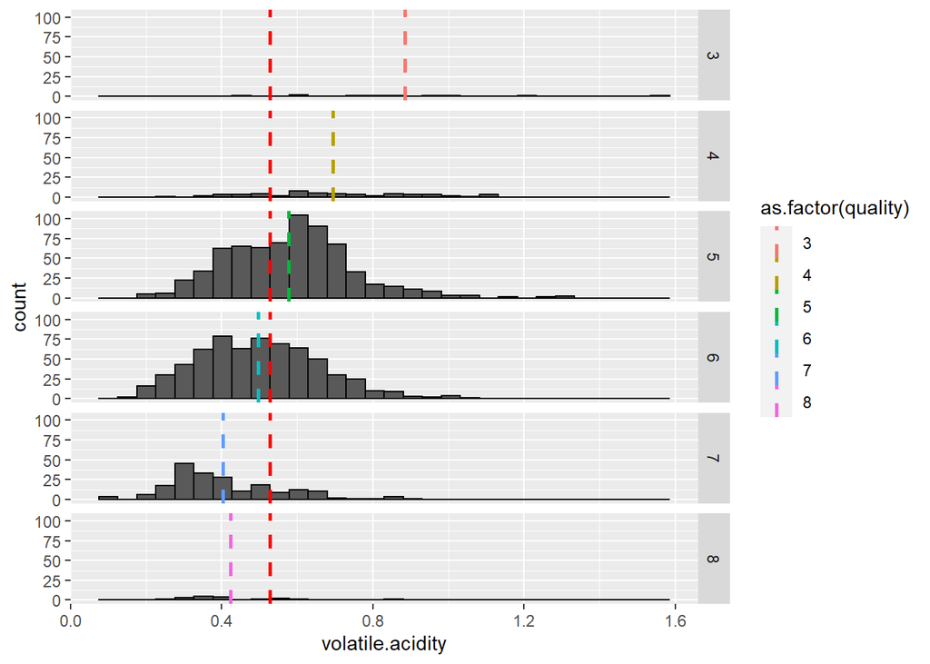

### Volatile Acidity for Different Qualities of Wine

This chart shows how the mean of volatile acidity for different tiers of wine quality goes down the higher one goes, until there is a slight uptick right at level 8.

# Multivariate Analysis

### Talk about some of the relationships you observed in this part of the investigation. Were there features that strengthened each other in terms of looking at your feature(s) of interest?

I wanted to try looking at sulfates and alcohol content in relation to quality one more time with a multivariate analysis. These two things were the most correlated with quality, after all.

The scatterplot featuring sulfates vs. alcohol content is there as well, with quality layered on as different colors.

### Were there any interesting or surprising interactions between features?

I was surprised that mid-quality (5) wines were so closely packed around their mean sulfate content and alcohol content. I am also surprised that alcohol and sulfates are hardly correlated at all! This means that they are separate, independent features that could predict quality of wines in an algorithm.

# Final Plots and Summary

### Residual Sugar in Red Wines

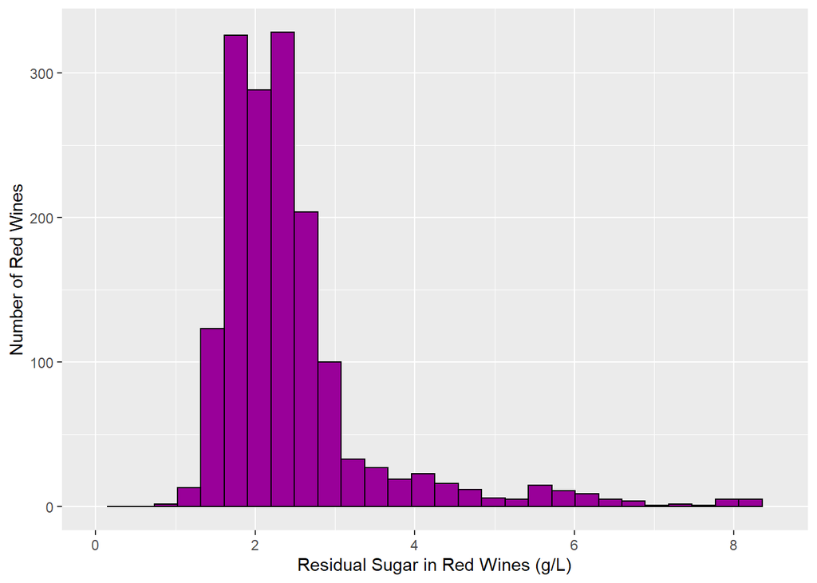

### Description

This plot shows the residual sugars in red wines. IF you wanted to fit in, you might make your wine have around 2.539 grams per liter of residual sugars, which is the mean. This particular chart had a long right tail, which I chopped off in order to make the graph more centralized.

### Fixed Acidity vs. Density in Red Wines

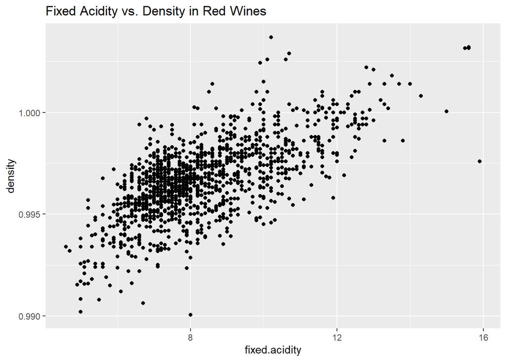

### Description

This graph shows fixed acidity vs. density. I was interested in seeing if there was a relationship, and there was a positive correlation of .668 . I checked out another online data set and found out that this was the case there as well.

### Volatile Acidity vs. Quality Rating

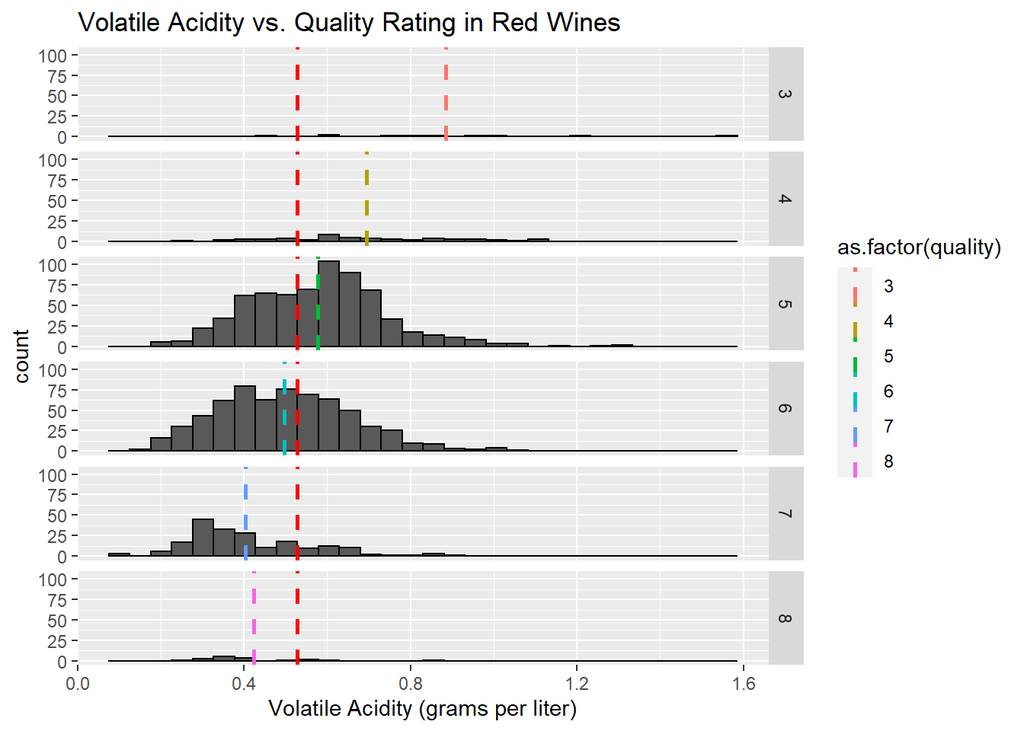

### Description

This graph looks at the relationships between volatile acidity and quality rating. Although the wine-industry insider I knew thought that volatile acidity did not matter for wine quality, it was the most negatively associated with wine quality out of all of the variables explored.

# Reflection

I found out that a multivariate analysis was better for exploring the relationship between things such as sulfates vs. quality than a scatterplot. I could not get a feel for those scatterplots that I made earlier in the exploration. I eventually learned how to use jitter to clear this up a bit.

I was personally interested in using this data set to learn a bit about chemistry and physics, while I think others might be interested in using it to learn what kinds of wines have a high quality rating. So I did a bit of both in the exploration.

The first two scatterplots I made, citric acid vs. fixed acidity and fixed acidity vs. density went well. In addition, the mass-production of correlation values as well as univariate charts went very well. Those gave a decent overview of the data, along with the data summary. I thought the multivariate analysis went well, but it is my first time doing one, and I am not sure.

I was surprised at the relationship between acidity and density. In the future, I would like to do more multivariate analysis with the quality variable, and see what I can find. As far as the wine industry goes, one surprising find was that volatile acidity was so negatively correlated with red wine quality! No one in the industry I talked to seemed to know that.